# Ford GoBike Exploration

## by Jonathan Obise

## Investigation Overview

> This data set includes information about individual rides made in a bike-sharing system covering the greater San Francisco Bay area.

> To prepare the data, I loaded it in from a csv file and converted the start and end time columns to datetime, extracted the dayofweek and hours information from the start_time variable and converted the start_time_dayofweek to ordinal variables.

## Dataset Overview

> Bay Wheels (Formerly Ford GoBike) is a regional public bicycle sharing system in California's San Francisco Bay Area. It is operated by Motivate in a partnership with the Metropolitan Transportation Commission and the Bay Area Air Quality Management District. Bay Wheels is 'the first regional and large-scale bicycle sharing system deployed in California and on the West Coast of the United States. It was established as Bay Area Bike Share in August 2013. As of January 2018, the Bay Wheels system had over 2,600 bicycles in 262 stations across San Francisco, East Bay and San Jose.

> In June 2017 the system was officially re-launched as Ford GoBike in a partnership with Ford Motor Company. After Motivate's acquisition by Lyft, the system was renamed to Bay Wheels in June 2019. The system is expected to expand to 7,000 bicycles around 540 stations in San Francisco, Oakland, Berkeley, Emeryville, and San Jose.

```python
#Convert the columns to the datetime
df_new['start_time'] = pd.to_datetime(df_new['start_time'])
df_new['end_time'] = pd.to_datetime(df_new['end_time'])
```

```python
# We can now extract the dayofweek and hours information from the start_time
df_new['start_time_dayofweek']= df_new['start_time'].dt.strftime('%a')
df_new['start_time_hour']= df_new['start_time'].dt.hour
```

```python
# This converts the start_time_dayofweek to ordinal variables.
week_days = ['Mon','Tue','Wed','Thu','Fri', 'Sat', 'Sun']
ordered_week_days = pd.api.types.CategoricalDtype(ordered = True, categories = week_days)
df_new['start_time_dayofweek'] = df_new['start_time_dayofweek'].astype(ordered_week_days)
```

```python
df_new['duration_min'] = df_new['duration_sec']/60
```

```python
df_new = df_new.query('duration_min <= 66')
df_new.info(null_counts=True)
```

```
<class 'pandas.core.frame.DataFrame'>
Int64Index: 173735 entries, 4 to 183411
Data columns (total 19 columns):
 #   Column                   Non-Null Count   Dtype
---  ------                   --------------   -----
 0   duration_sec             173735 non-null  int64
 1   start_time               173735 non-null  datetime64[ns]
 2   end_time                 173735 non-null  datetime64[ns]
 3   start_station_id         173735 non-null  float64
 4   start_station_name       173735 non-null  object
 5   start_station_latitude   173735 non-null  float64
 6   start_station_longitude  173735 non-null  float64
 7   end_station_id           173735 non-null  float64
 8   end_station_name         173735 non-null  object
 9   end_station_latitude     173735 non-null  float64
 10  end_station_longitude    173735 non-null  float64
 11  bike_id                  173735 non-null  int64
 12  user_type                173735 non-null  object
 13  member_birth_year        173735 non-null  float64
 14  member_gender            173735 non-null  object
 15  bike_share_for_all_trip  173735 non-null  object
 16  start_time_dayofweek     173735 non-null  category
 17  start_time_hour          173735 non-null  int64
 18  duration_min             173735 non-null  float64
dtypes: category(1), datetime64[ns](2), float64(8), int64(3), object(5)
memory usage: 25.4+ MB
```

```python
# Compute member_age from member_birth_year.
df_new['member_age'] = 2021 - df_new['member_birth_year']
```

```python
df_new['member_age'] = df_new['member_age'].astype(int)
df_new['member_birth_year'] = df_new['member_birth_year'].astype(int)
```

```python
df_new = df_new[df_new.member_age <= 60]
```

## (Visualization 1)

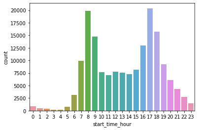

```python
#Plot the bike sharing service during the day
sb.countplot(data = df_new, x = 'start_time_hour')
```

## (Visualization 2)

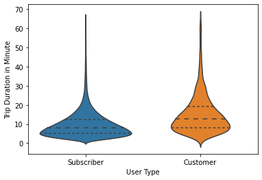

```python
# Plot a violin plot to investigate how the trip duration distribution between customers and subscribers
sb.violinplot(data=df_new, x='user_type', y='duration_min', inner='quartile');
plt.xlabel('User Type');
plt.ylabel('Trip Duration in Minute');
```

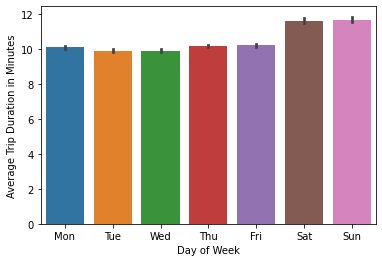

```python
# Visualize the average trip duration on weekdays
sb.barplot(data=df_new, x='start_time_dayofweek', y='duration_min');
plt.xlabel('Day of Week');
plt.ylabel('Average Trip Duration in Minutes');
```

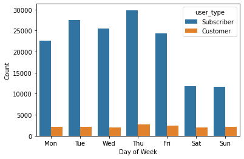

```python
# Visualize the weekly usage by customers and subscribers
sb.countplot(data=df_new, x='start_time_dayofweek', hue='user_type');
plt.xlabel('Day of Week');
plt.ylabel('Count');
```

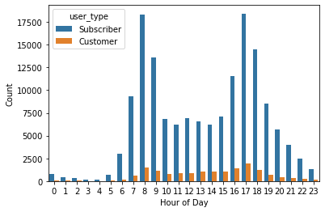

```python
# Visualize the daily usage by customers and subscribers
sb.countplot(data=df_new, x='start_time_hour', hue='user_type');
plt.xlabel('Hour of Day');
plt.ylabel('Count');
```

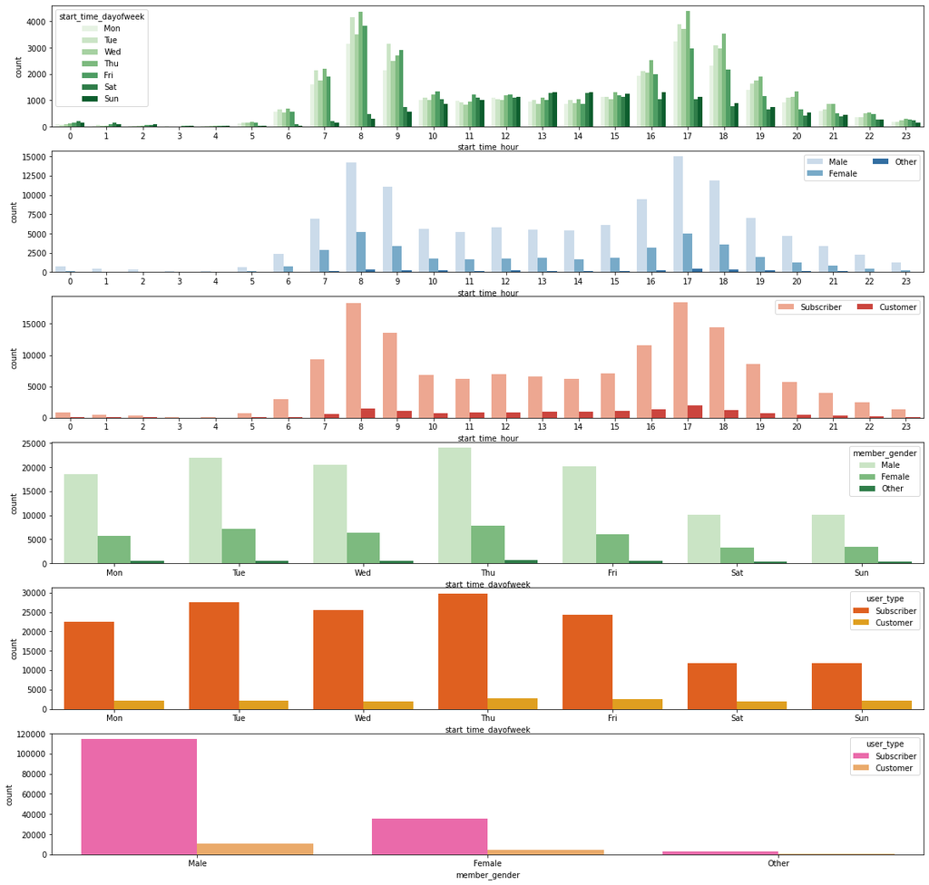

```python
# Visualize all the plots together
plt.figure(figsize = [20, 20]);

plt.subplot(6, 1, 1);
sb.countplot(data = df_new, x = 'start_time_hour', hue = 'start_time_dayofweek', palette = 'Greens');

ax = plt.subplot(6, 1, 2);
sb.countplot(data = df_new, x = 'start_time_hour', hue = 'member_gender', palette = 'Blues');
ax.legend(ncol = 2); # re-arrange legend to reduce overlapping

ax = plt.subplot(6, 1, 3);
sb.countplot(data = df_new, x = 'start_time_hour', hue = 'user_type', palette = 'Reds');
ax.legend(loc = 1, ncol = 2);

ax = plt.subplot(6, 1, 4);
sb.countplot(data = df_new, x = 'start_time_dayofweek', hue = 'member_gender', palette = 'Greens');

ax = plt.subplot(6, 1, 5);
sb.countplot(data = df_new, x = 'start_time_dayofweek', hue = 'user_type', palette = 'autumn');

ax = plt.subplot(6, 1, 6);
sb.countplot(data = df_new, x = 'member_gender', hue = 'user_type', palette = 'spring');
```

## (Visualization 3)

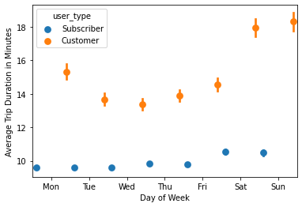

```python
#Visualize the average trip dution during weekdays between subscribers and customers
sb.pointplot(data=df_new, x='start_time_dayofweek', y='duration_min', hue='user_type', dodge=0.8, linestyles="");
plt.xlabel('Day of Week');
plt.ylabel('Average Trip Duration in Minutes');
```

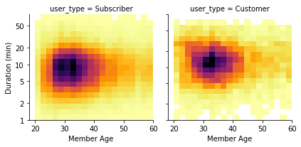

```python
# Plot the duration of customers and subscribers
g = sb.FacetGrid(data = df_new, col = 'user_type', height = 3);
g.map(histgrid, 'member_age', 'log_duration_min', color = 'inferno_r');
g.set_xlabels('Member Age');
g.set_ylabels('Duration (min)');
```

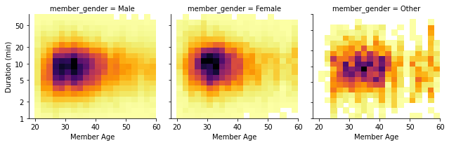

```python
# Plot the duration of customers and subscribers
g = sb.FacetGrid(data = df_new, col = 'member_gender', height = 3);
g.map(histgrid, 'member_age', 'log_duration_min', color = 'inferno_r');
g.set_xlabels('Member Age');
g.set_ylabels('Duration (min)');
```